# Data Visualization with ggplot2

Visualizing data is an area where R really shines. There are many ways to plot data with R and these include base R, `lattice`,`grid` and , `ggplot2`. The only one we will work with is `ggplot2`, which is now (I have no data to back this up), the de-facto standard for visualizing data in R. Given that `ggplot2` is general package for creating essentially ALL types of visualizations, it can seem quite complex (and it is). What I hope you will get out of this section is a basic understanding of how to create a figure and, most importantly, how to find help and examples that you can build off of for your own visualizations. If you want to read more about why some people choose base plotting vs `ggplot2`, the twitter/blogosphere “argument” between [Jeff Leek](https://simplystatistics.org/2016/02/11/why-i-dont-use-ggplot2/) and [David Robinson](http://varianceexplained.org/r/why-I-use-ggplot2/) is worth some time.

## Lesson Outline

- Examples
- Basics of `ggplot2`
- Example explained

## Exercise

- Homework 4.1

## Examples

Before we get started, I do like to show what is possible.

A few examples of maps built with R show this:

[figure not shown]

Trophic State Modeling Results

[figure not shown]

Facebook Users

And some fairly complicated figures:

[figure not shown]

psych_repro

More examples from Jeff’s (and Kenny’s!) work

[figure not shown]

from: Raposa et al. (2018). Top-down and bottom-up controls on overabundant New England salt marsh crab populations. PeerJ. https://doi.org/10.7717/peerj.4876

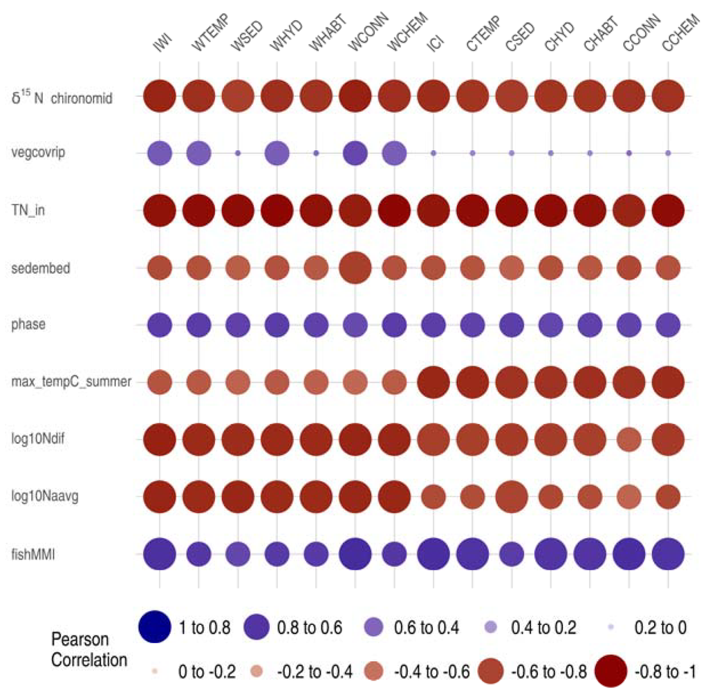

from: Kuhn et al. (2018) Performance of national maps of watershed integrity at watershed scales. Water. https://doi.org/10.3390/w10050604

And some cool examples using `ggplot2` with `plotly`.

http://blog.revolutionanalytics.com/2014/11/3-d-plots-with-plotly.html

Lastly, so that you know that there are many (often cool) mistakes that lead up to a final visualization there is [Accidental aRt](http://accidental-art.tumblr.com/). And for a specific example …

And the map I showed earlier of the trophic state probability had as one of its early iterations this [“psychadelic doughnut”](http://accidental-art.tumblr.com/post/96720455195/was-trying-to-mess-with-projections-in-ggplot)

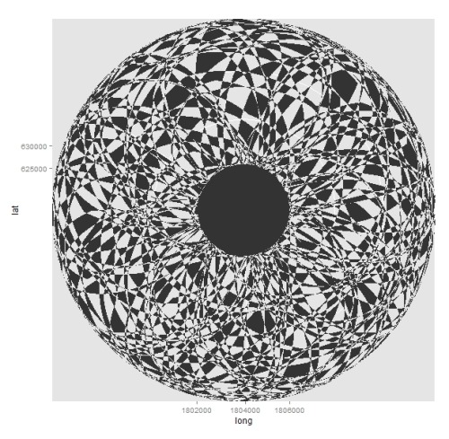

pd

(**ht to Anne Kuhn, my office mate, for the name**)

A few other great links that I have recently found are also useful for inspiration. First, is a repository on GitHub that has most (all?) of the currently available color palletes in R: https://github.com/EmilHvitfeldt/r-color-palettes. Second, the [R graph gallery](https://www.r-graph-gallery.com/) is a fantastic resource for seeing all that is possible for visualization in R and the code on how to do it!!

Now that we are sufficiently motivated, lets take a step back to the very basics.